# alumni_report

James Sugawara

12/12/2021

```r
library(dplyr)
```

```r
library(scales)
library(ggplot2)
library(readr)
alum <- read_csv("alum_surv.csv")
```

Consolidating similar job titles into one, and grad school focuses into one

```r
alum <- rename(alum, job_title = `What is your current job position / title?`,
               grad_trade_pro_degree = `In what area is the degree you obtained / are obtaining ?`)

alum <- alum %>% mutate(
  job = case_when(
    grepl('Data Analyst|Analyst|Data Analytic', job_title) ~ "Data Analyst",
    grepl('Data Scien', job_title)  ~ "Data Scientist",
    grepl('Consult|consult', job_title) ~ "Consultant",
    grepl('Business Analy', job_title) ~ "Business Analyst",
    grepl('Teacher|Profess|Teaching', job_title) ~ "Academic Instructor",
    grepl('Biostat', job_title) ~ "Biostatistician",
    grepl('Engineer', job_title) ~ "Software Engineer",
    grepl('Statistician|statistician', job_title) ~ "Statistician",
    grepl("Actuar|actuar", job_title) ~ "Actuary",
    grepl("Program", job_title) ~ "Programmer",
    grepl("Research", job_title) ~ "Researcher",
    grepl("Software", job_title) ~ "Software Developer",
    TRUE ~ job_title

   )
  )

alum <- alum %>% mutate(
  masters = grad_trade_pro_degree,
  masters = case_when(
    grepl("Biostat", grad_trade_pro_degree) ~ "Biostatistics",
    grepl("Statistics", grad_trade_pro_degree) ~ "Statistics",
    grepl("Education", grad_trade_pro_degree) ~ "Education",
    grepl("Business", grad_trade_pro_degree) ~ "Business",
    grepl("Informatics|informatics", grad_trade_pro_degree) ~ "Informatics",
    TRUE ~ grad_trade_pro_degree
  )
)
```

Proportion of respondents who graduated before (0) and after (1) 2013

```r
alum$since2014 <- ifelse(alum$`What year did you graduate from the Cal Poly Statistics Department` >= 2014, 1, 0)
prop.table(table(alum$since2014))
```

```
##
##         0         1
## 0.4811321 0.5188679
```

```r
alum %>% filter(grepl('SAS', `Which software and programming language(s) do you use/have you used since graduating from Cal Poly? (Select all that apply).`)) %>% filter(`What year did you graduate from the Cal Poly Statistics Department` >= 2017) %>% nrow()
```

```
## [1] 5
```

```r
alum %>% filter(grepl('Excel', `Which software and programming language(s) do you use/have you used since graduating from Cal Poly? (Select all that apply).`)) %>% filter(`What year did you graduate from the Cal Poly Statistics Department` >= 2017) %>% nrow()
```

```
## [1] 27
```

```r
alum %>% filter(grepl('SQL|sql', `Which software and programming language(s) do you use/have you used since graduating from Cal Poly? (Select all that apply).`)) %>% filter(`What year did you graduate from the Cal Poly Statistics Department` >= 2014) %>% nrow()
```

```
## [1] 39
```

Finding the gender proportion/count of respondents

```r
(table(alum$Gender))
```

```
##
##                             Decline to state
##                                            1
##                                          Man
##                                           56
## Odd choice selection from a Statistics Dept.
##                                            1
##                                        Woman
##                                           48
```

```r
median(alum$`What year did you graduate from the Cal Poly Statistics Department`)
```

```
## [1] 2014
```

```r
summary((alum$`What year did you graduate from the Cal Poly Statistics Department`))
```

```
##    Min. 1st Qu.  Median    Mean 3rd Qu.    Max.
##    1977    2009    2014    2012    2018    2021
```

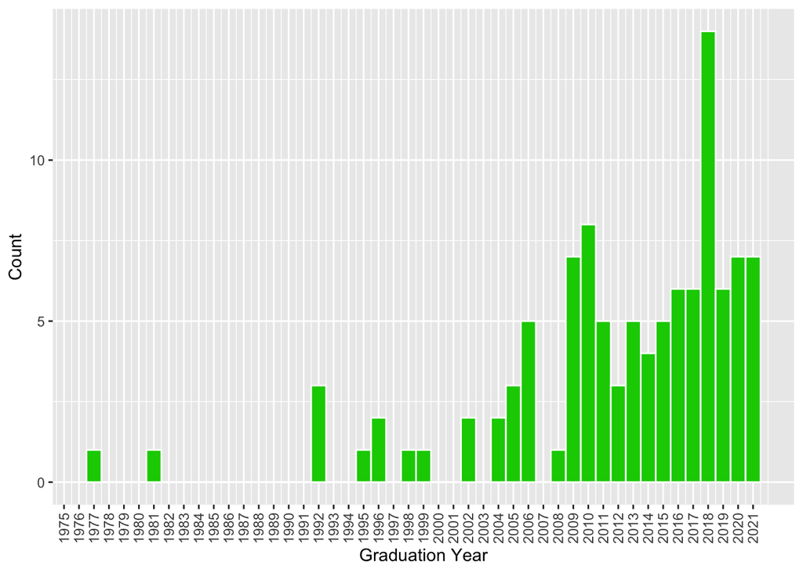

```r
ggplot(alum, aes(x=`What year did you graduate from the Cal Poly Statistics Department`)) +
  geom_histogram(binwidth=1, fill = "green3", color = "white") +
  ylab("Count") + xlab("Graduation Year") +
  theme(axis.text.x=element_text(angle=90,hjust=1,vjust=0.5)) +
  scale_x_continuous(breaks = 1971:2021)
```

Finding proportion of respondents who changed majors to Statistics

```r
prop.table(table(alum$`Did you change your major to statistics at Cal Poly?`))
```

```
##
## No, I did not change majors to statistics
##                                 0.6037736
##       Yes, I changed majors to statistics
##                                 0.3962264
```

Finding when respondents who changed majors made the switch

```r
prop.table(table(alum$`When did you change to the statistics major at Cal Poly?`))
```

```
##
##  Changed majors as a first year Changed majors as a fourth year
##                      0.19047619                      0.07142857
## Changed majors as a second year  Changed majors as a third year
##                      0.38095238                      0.35714286
```

Finding which major they changed from

```r
(table(alum$`What major did you change from?`))
```

```
##
##                          Biochemistry, BS
##                                         1
##                   Biological Sciences, BS
##                                         2
##                Biomedical Engineering, BS
##                                         1
##               Business Administration, BS
##                                         5
##                     Civil Engineering, BS
##                                         1
##                 Communication Studies, BA
##                                         1
##                      Computer Science, BS
##                                         2
## Environmental Earth and Soil Sciences, BS
##                                         1
##                           Mathematics, BS
##                                        25
##                                     Other
##                                         1
##                  Software Engineering, BS
##                                         1
```

Finding whether respondents changed institutions, and if yes, if from a four year college or a CC.

```r
prop.table(table(alum$`Did you transfer from another institution?`))
```

```
##
##                            No    Yes, from a 4-year college
##                   0.877358491                   0.009433962
## Yes, from a community college
##                   0.113207547
```

Finding the highest level of education of respondents

```r
prop.table(table(alum$`What is the highest level of education you have completed or are in the progress of completing?`))
```

```
##
##   Bachelor's Degree     Doctoral Degree     Master's Degree Professional Degree
##         0.556603774         0.075471698         0.358490566         0.009433962
```

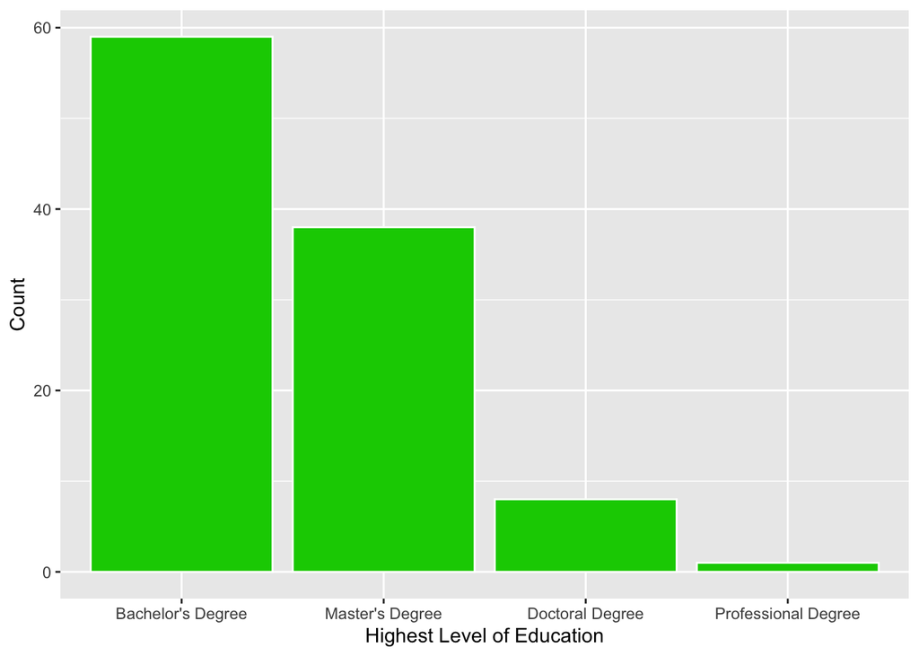

```r
alum$`What is the highest level of education you have completed or are in the progress of completing?`<- factor(alum$`What is the highest level of education you have completed or are in the progress of completing?`, levels = c("Bachelor's Degree", "Master's Degree", "Doctoral Degree", "Professional Degree"))
ggplot(alum, aes(x=`What is the highest level of education you have completed or are in the progress of completing?`)) +
  geom_bar(fill = "green3", color = "white") +
  ylab("Count") + xlab("Highest Level of Education")
```

Finding proportion of respondetns thatare employed

```r
prop.table(table(alum$`Are you currently employed?`))
```

```
##
##         No        Yes
## 0.05660377 0.94339623
```

```r
prop.table(table(alum$`Why are you not employed?`))
```

```
##
##  I am still in graduate school           I choose not to work
##                      0.3333333                      0.3333333
## I've been retired for 7 years.                        retired
##                      0.1666667                      0.1666667
```

Finding whether respondents work full time or not

```r
(table(alum$`Do you work full time or part time?`))
```

```
##
##   Full time (30 hours or more per week) Part time (Less than 30 hours per week)
##                                      96                                       4
```

Finding how long respondents have been at their current job

```r
prop.table(table(alum$`How long have you been at this job?`))
```

```
##
##     1 to 3 years     4 to 6 years         7+ years Less than 1 year
##             0.34             0.17             0.26             0.23
```

Finding proportion of respondents that are satisfied with their job

```r
(table(alum$`Are you satisfied with your current job?`))
```

```
##
##  No Yes
##  10  90
```

Finding how often respondents use statistics they learned at Cal Poly in their job

```r
prop.table(table(alum$`How often do you use the statistical knowledge you received at Cal Poly in your job?`))
```

```
##
##      Never      Often     Rarely  Sometimes Very often
##       0.02       0.25       0.16       0.31       0.26
```

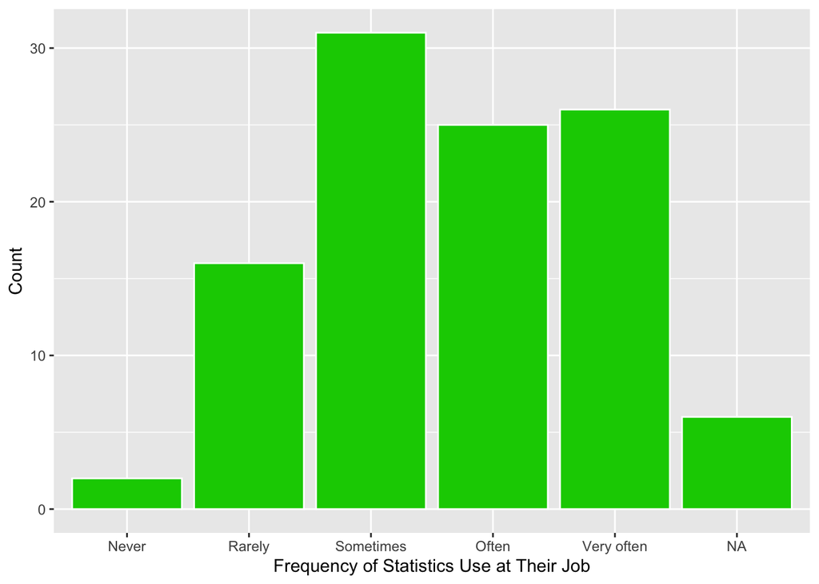

```r
alum$`How often do you use the statistical knowledge you received at Cal Poly in your job?` <- factor(alum$`How often do you use the statistical knowledge you received at Cal Poly in your job?`, levels = c("NA", "Never", "Rarely", "Sometimes", "Often", "Very often"))
ggplot(alum, aes(x=`How often do you use the statistical knowledge you received at Cal Poly in your job?`)) +
  geom_bar(fill = "green3", color = "white") +
  ylab("Count") + xlab("Frequency of Statistics Use at Their Job")
```

Finding how easy/hard it was for respondents to find their first full-time job

```r
(table(alum$`How easy or difficult was it for you to find your first full-time job or pursue your chosen professional path after graduation from Cal Poly?`))
```

```
##
##               Easy            Neutral Somewhat difficult     Very difficult
##                 21                 33                 14                  6
##          Very easy
##                 26
```

Finding how respondents would rate how well they learned various important statistical ideas

```r
(table(alum$`The quality of my foundation in _______ that I learned at Cal Poly was: [Statistical theory]`))
```

```
##
##   Average Excellent      Good      Poor Very poor
##        15        43        45         2         1
```

```r
(table(alum$`The quality of my foundation in _______ that I learned at Cal Poly was: [Statistical methods]`))
```

```
##
##   Average Excellent      Good Very poor
##         6        56        43         1
```

```r
(table(alum$`The quality of my foundation in _______ that I learned at Cal Poly was: [Statistical applications]`))
```

```
##
##   Average Excellent      Good      Poor
##        10        51        43         2
```

```r
(table(alum$`The quality of my foundation in _______ that I learned at Cal Poly was: [Statistical programming]`))
```

```
##
##   Average Excellent      Good      Poor
##        16        49        37         4
```

```r
#already included in the q about highest lvl of education
prop.table(table(alum$`Did you attend graduate school, trade school, or professional school?`))
```

```
##
## Currently attending                  No                 Yes
##           0.0754717           0.5377358           0.3867925
```

```r
prop.table(table(alum$`In what area is the degree you obtained / are obtaining ?`))
```

```
## numeric(0)
```

```r
(table(alum$`In what area is the degree you obtained / are obtaining ?`))
```

```
## < table of extent 0 >
```

Finging how respondents rate their preparation in undergrad compared to their peers at graduate school

```r
prop.table(table(alum$`Would you say the quality of your Cal Poly undergraduate statistics training compared to other graduate/professional/trade school students was:`))
```

```
##
##   About the same Better than most
##        0.2653061        0.7346939
```

Finding how prepared/unprepared respondents felt from various experiences in the statistics program

```r
(table(alum$`To what extent did you feel prepared or unprepared for your first job or graduate school based on the following with the Cal Poly statistics department?  [Coursework]`))
```

```
##
##                 N/A             Neutral   Somewhat prepared Somewhat unprepared
##                   4                   9                  32                   3
##       Very prepared     Very unprepared
##                  57                   1
```

```r
(table(alum$`To what extent did you feel prepared or unprepared for your first job or graduate school based on the following with the Cal Poly statistics department?  [Capstone experiences (ie: senior project, another class)]`))
```

```
##
##                 N/A             Neutral   Somewhat prepared Somewhat unprepared
##                   6                   8                  27                   4
##       Very prepared     Very unprepared
##                  60                   1
```

```r
(table(alum$`To what extent did you feel prepared or unprepared for your first job or graduate school based on the following with the Cal Poly statistics department?  [Experiences with statistical software]`))
```

```
##
##                 N/A             Neutral   Somewhat prepared Somewhat unprepared
##                   3                  14                  23                   3
##       Very prepared     Very unprepared
##                  62                   1
```

Graphically displaying the different preparedness levels of respondents based on their expereinces in the statistics program

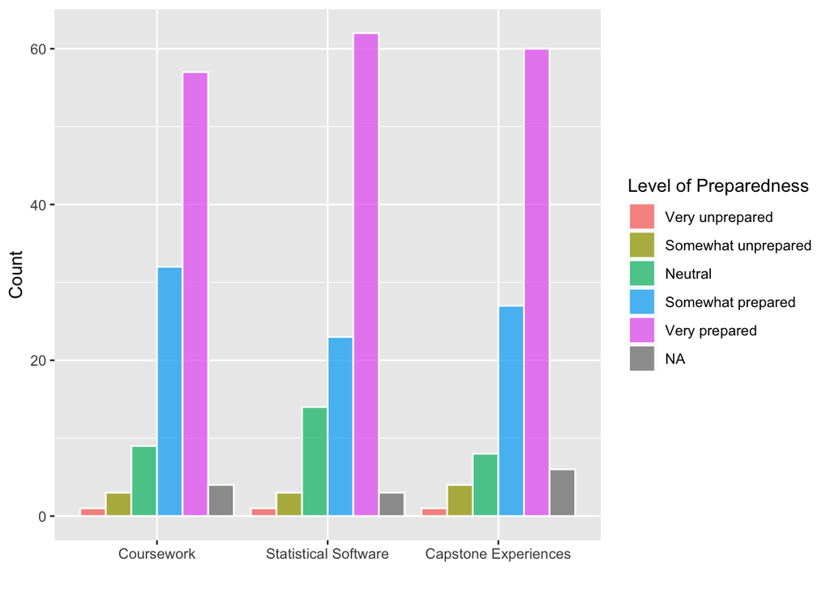

```r
colnames(alum)[33] <- "Coursework"
colnames(alum)[34] <- "Statistical Software"
colnames(alum)[35] <- "Capstone Experiences"

alum$Coursework <- as.vector(alum$Coursework)
alum$`Statistical Software` <- as.vector(alum$`Statistical Software`)
alum$`Capstone Experiences` <- as.vector(alum$`Capstone Experiences`)

prep_sub <- stack(alum[33:35])

alum$Coursework <- factor(alum$Coursework, levels = c("Very unprepared", "Somewhat unprepared", "Neutral", "Somewhat prepared", "Very prepared"))
alum$`Statistical Software` <- factor(alum$`Statistical Software`, levels = c("Very unprepared", "Somewhat unprepared", "Neutral", "Somewhat prepared", "Very prepared"))
alum$`Capstone Experiences` <- factor(alum$`Capstone Experiences`, levels = c("Very unprepared", "Somewhat unprepared", "Neutral", "Somewhat prepared", "Very prepared"))

prep_sub$values <- factor(prep_sub$values, levels = c("Very unprepared", "Somewhat unprepared", "Neutral", "Somewhat prepared", "Very prepared"))

ggplot(data = prep_sub, aes(x = ind, fill = values)) +
  geom_bar(stat = "count", position = position_dodge(), alpha = 0.75, color = "white") +
  xlab("") + ylab("Count") + labs(fill = "Level of Preparedness")
```

Finding how well versed respondents felt with their non-mathematical skills from the statistics program

```r
prop.table(table(alum$`Do you feel as though you learned enough non-mathematical statistics related skills at Cal Poly via your statistics courses?      [Technical writing]`))
```

```
##
##        No       Yes
## 0.3584906 0.6415094
```

```r
prop.table(table(alum$`Do you feel as though you learned enough non-mathematical statistics related skills at Cal Poly via your statistics courses?      [Presentation skills]`))
```

```
##
##        No       Yes
## 0.2830189 0.7169811
```

```r
prop.table(table(alum$`Do you feel as though you learned enough non-mathematical statistics related skills at Cal Poly via your statistics courses?      [Teamwork/collaboration]`))
```

```
##
##         No        Yes
## 0.08490566 0.91509434
```

```r
prop.table(table(alum$`Do you feel as though you learned enough non-mathematical statistics related skills at Cal Poly via your statistics courses?      [Planning for data collection]`))
```

```
##
##        No       Yes
## 0.2075472 0.7924528
```

```r
prop.table(table(alum$`Do you feel as though you learned enough non-mathematical statistics related skills at Cal Poly via your statistics courses?      [Data management]`))
```

```
##
##        No       Yes
## 0.4528302 0.5471698
```

Finding areas where respondents think the statistics program can offer more focus

```r
prop.table(table(alum$`Should the Cal Poly Statistics department offer more courses in data mining or data visualization than when you were a student, or were there enough courses like this available to you?  [Data mining]`))
```

```
##
## No, there were enough of these types of courses available.
##                                                  0.1509434
##                        Yes, more courses should be offered
##                                                  0.8490566
```

```r
prop.table(table(alum$`Should the Cal Poly Statistics department offer more courses in data mining or data visualization than when you were a student, or were there enough courses like this available to you?  [Data visualization]`))
```

```
##
## No, there were enough of these types of courses available.
##                                                  0.1886792
##                        Yes, more courses should be offered
##                                                  0.8113208
```

```r
(table(alum$`Would you recommend the Cal Poly statistics major to a friend or family member who is a high school senior interested in statistics?`))
```

[output not shown]